# Homework 2

¶ ¶

¶ < Jacob Fisher > ¶

## Data and Description

One key component of determining appropriate speed limits is the amount of distance that is required to stop at a given speed. For example, in residential neighborhoods, when pedestrians are commonly in the roadways, it is important to be able to stop in a very short distance to ensure pedestrian safety. The speed of vehicles may be useful for determining the distance required to stop at that given speed, which can aid public officials in determining speed limits.

The Stopping Distance data set compares the **distance (column 2)** (in feet) required for a car to stop on a certain rural road against the **speed (column 1)** (MPH) of the car. Download the StoppingDistance.txt file from Learning Suite, and put it in the same folder as this R Markdown file.

There’s one thing we’re going to ignore. When the speed is 0 MPH, then the stopping distance is 0 ft. We won’t impose this in the model, but it’s pretty easy to do.

#### 0. Replace the text “< PUT YOUR NAME HERE >” (above next to “author:”) with your full name.

#### 1. Read in the data set, and call the tibble “stop”. Print a summary of the data and make sure the data makes sense.

```r
stop<-read.csv("StoppingDistance.txt", header= T, sep = " ")
summary(stop)
```

```
##      Speed          Distance
##  Min.   : 4.00   Min.   :  2.00
##  1st Qu.:10.00   1st Qu.: 13.25
##  Median :17.50   Median : 29.50
##  Mean   :18.92   Mean   : 39.31
##  3rd Qu.:26.75   3rd Qu.: 56.75
##  Max.   :40.00   Max.   :138.00
```

#### 2. Create a scatterplot of the data with variables on the appropriate axes (think about which variable makes the most sense to be the response). Make you plot look professional (make sure the axes labels are descriptive, the plot is square, etc.).

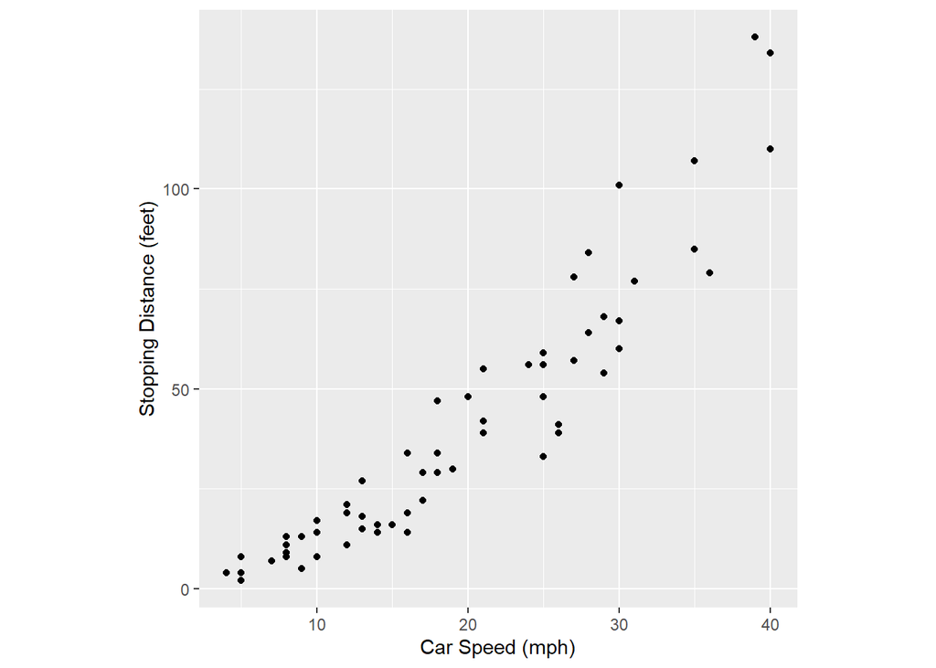

```r
stop_base_plot <- ggplot(data = stop) +
  geom_point(mapping = aes(Speed, Distance)) +
  theme(aspect.ratio = 1) +
  xlab("Car Speed (mph)") + ylab("Stopping Distance (feet)")
stop_base_plot
```

#### 3. Briefly describe the relationship between Speed and Distance. (Hint: you should use 2 or 3 key words.)

Speed and distance appear to be positively correlated in a strong linear fashion.

#### 4. Add the OLS regression line to the scatterplot you created in question 2 (note: if you receive a warning about rows with missing values, you may need to adjust an axis limit using `scale_y_continuous(limits = c(###, ###))`).

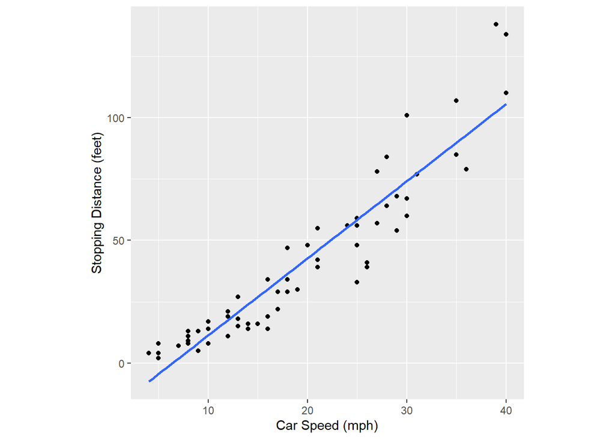

```r
stop_base_plot +
  geom_smooth(mapping = aes(x = Speed, y = Distance),
              method = "lm",
              se = FALSE)
```

#### 5. (a) Apply linear regression to the data(no transformations). (b) Print out a summary of the results from the `lm` function. (c) Save the residuals and fitted values to the `stop` tibble.

```r
stop.lm <- lm(Distance ~ Speed, data = stop)
summary(stop.lm)
```

```
##
## Call:
## lm(formula = Distance ~ Speed, data = stop)
##
## Residuals:
##     Min      1Q  Median      3Q     Max
## -25.410  -7.343  -1.334   5.927  35.608
##
## Coefficients:
##             Estimate Std. Error t value Pr(>|t|)
## (Intercept) -20.1309     3.2308  -6.231 5.04e-08 ***
## Speed         3.1416     0.1514  20.751  < 2e-16 ***
## ---
## Signif. codes:  0 '***' 0.001 '**' 0.01 '*' 0.05 '.' 0.1 ' ' 1
##
## Residual standard error: 11.77 on 60 degrees of freedom
## Multiple R-squared:  0.8777, Adjusted R-squared:  0.8757
## F-statistic: 430.6 on 1 and 60 DF,  p-value: < 2.2e-16
```

```r
stop$residuals <- stop.lm$residuals
stop$fitted_Distance <- stop.lm$fitted.values
```

### Questions 7-12 involve using diagnostics to determine if the linear regression assumptions are met. For each assumption, (1) perform appropriate diagnostics to determine if the assumption is violated, and (2) explain whether or not you think the assumption is violated and why you think that.

#### 7. (L) X vs Y is linear (use at least two diagnostic tools)

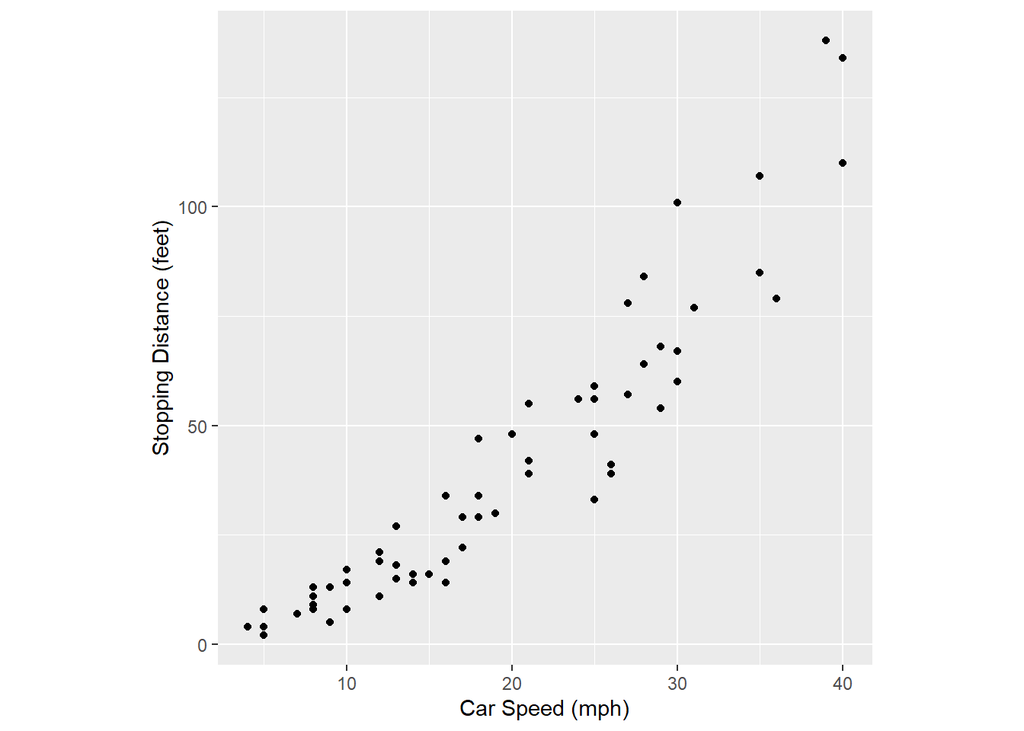

```r
#Scatterplot
stop_base_plot <- ggplot(data = stop) +
  geom_point(mapping = aes(Speed, Distance)) +
  theme(aspect.ratio = 1) +
  xlab("Car Speed (mph)") + ylab("Stopping Distance (feet)")
stop_base_plot
```

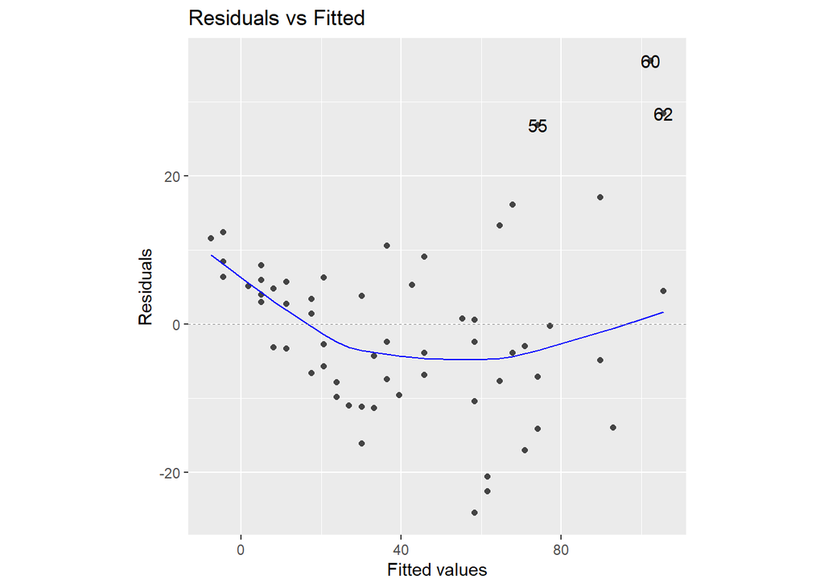

```r
#Resid v. fitted values
stop_resid_vs_fit <- autoplot(stop.lm, which = 1, ncol = 1, nrow = 1) +
  theme(aspect.ratio = 1)
stop_resid_vs_fit
```

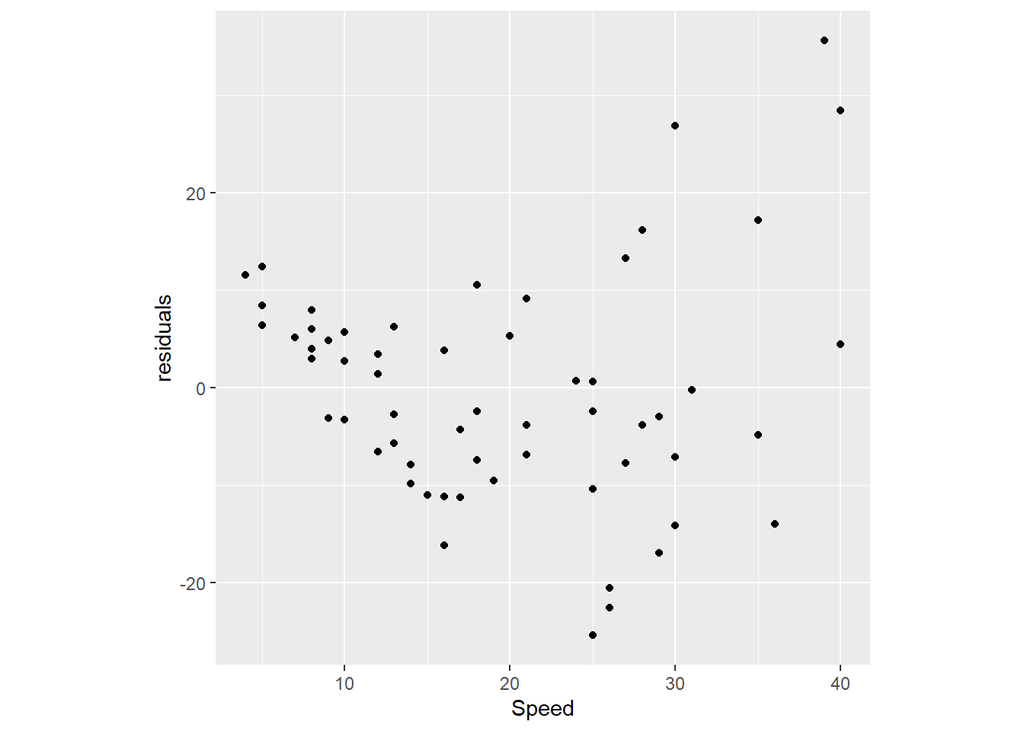

```r
#Resid v. predicted value
ggplot(data = stop) +
  geom_point(mapping = aes(x = Speed, y = residuals)) +
  theme(aspect.ratio = 1)
```

Based on our scatterplot, we may reasonably say that there is a linear relationship, although when looking at the Residual v. Fitted and Residual v. Predicted Values plots, we may be less comfortable making the linearity assumption.

#### 8. (I) The residuals are independent (no diagnostic tools - just think about how the data was collected and briefly write your thoughts)

This assumption is difficult to test statistically unless we know the data are in a natural order. Generally, if you have a random sample, the residuals will be independent. We do not have any indication of how the data was collected, so we cannot tell if the assumption is met.

#### 9. (N) The residuals are normally distributed and centered at zero (use at least three diagnostic tools)

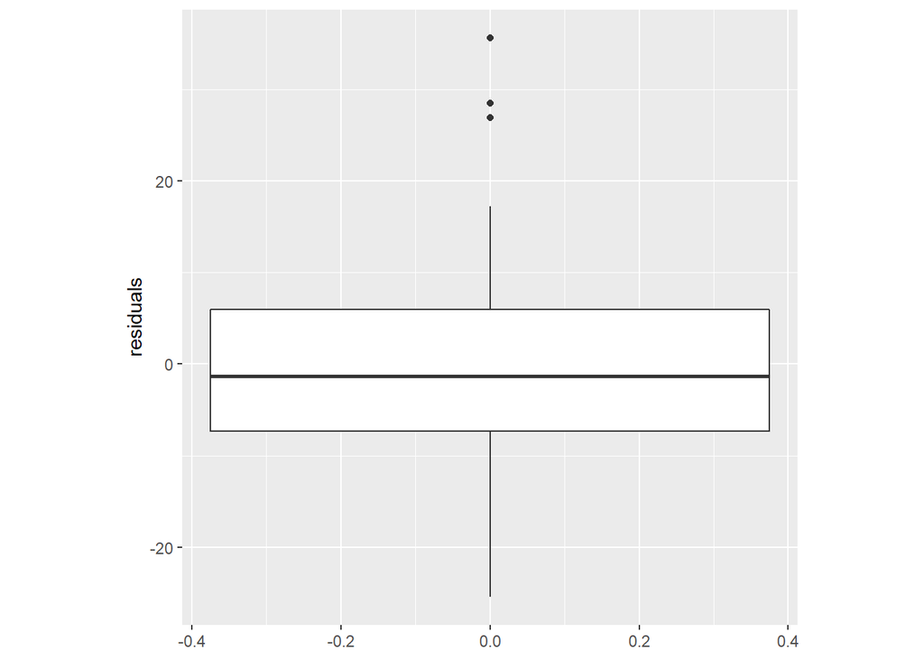

```r
#Boxplot
stop_boxplot <- ggplot(data = stop) +
  geom_boxplot(mapping = aes(y = residuals)) +
  theme(aspect.ratio = 1)
stop_boxplot
```

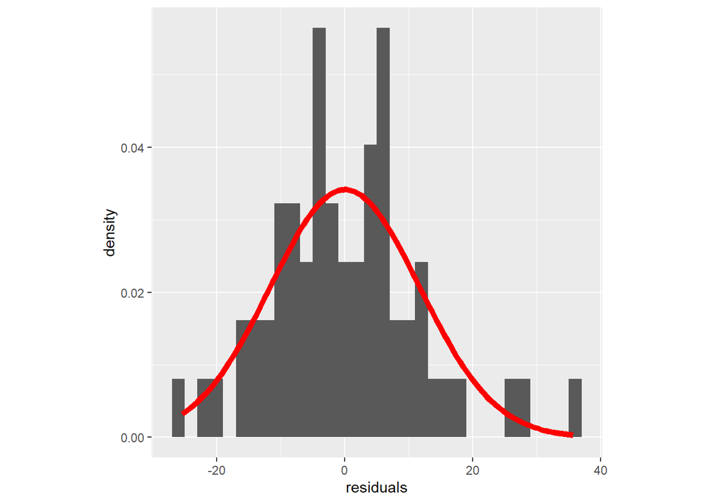

```r
#Histogram
stop_hist <- ggplot(data = stop) +
  geom_histogram(mapping = aes(x = residuals, y = ..density..), #..density.. allows us to compare to a normal curve
                 binwidth = 2) +
  stat_function(fun = dnorm, #overlays normal curve
                color = "red",
                size = 2,
                args = list(mean = mean(stop$residuals),
                            sd = sd(stop$residuals))) +
  theme(aspect.ratio = 1)
stop_hist
```

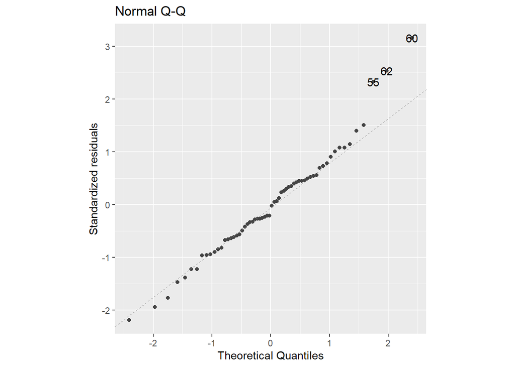

```r
#QQ-Plot
stop_qq <- autoplot(stop.lm, which = 2, ncol = 1, nrow = 1) +
  theme(aspect.ratio = 1)
stop_qq
```

The boxplot suggests normality with the exception of the three outliers at the top, which suggest a slight right-skewness. The histogram expresses the same right skewness, but relative normality. Our QQ-plot again highlights our outliers which warrant our attention.

#### 10. (E) The residuals have equal/constant variance across all values of X (use two diagnostic tools)

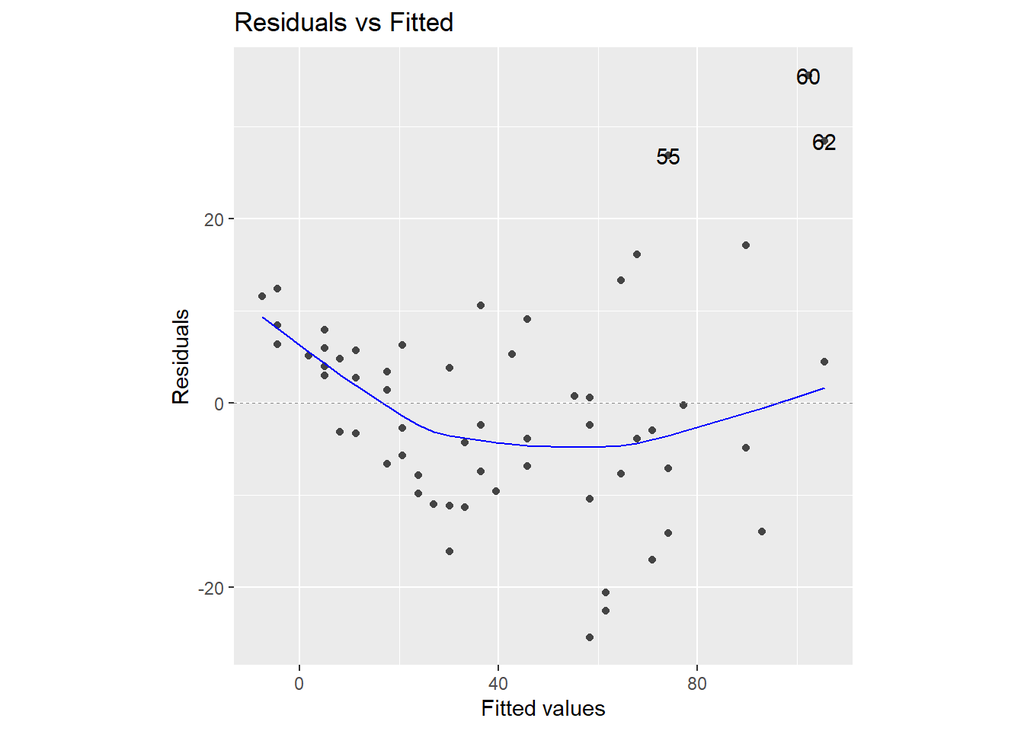

```r
#Resid v. fitted values
stop_resid_vs_fit
```

```r
#Breusch-Pagan
lmtest::bptest(stop.lm)
```

```
##
##  studentized Breusch-Pagan test
##
## data:  stop.lm
## BP = 14.535, df = 1, p-value = 0.0001376
```

#### 11. Examine whether there are no influential points (use at least three diagnostic tools)

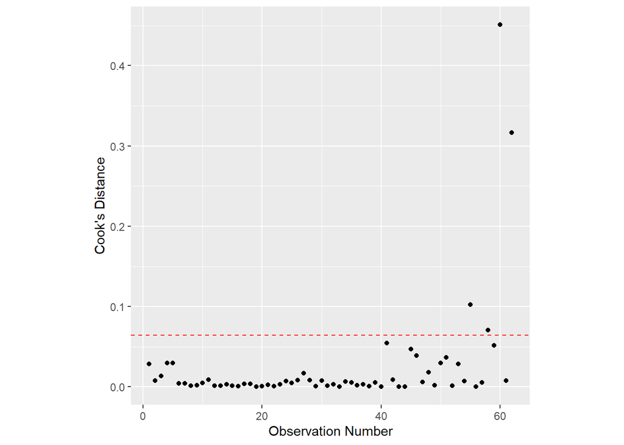

```r
# get Cook's distance values for all observations
stop$cooksd <- cooks.distance(stop.lm)

# plot Cook's distance against the observation number
ggplot(data = stop) +
  geom_point(mapping = aes(x = as.numeric(rownames(stop)),
                           y = cooksd)) +
  ylab("Cook's Distance") +
  xlab("Observation Number") +
  geom_hline(mapping = aes(yintercept = 4 / length(cooksd)),
             color = "red",
             linetype = "dashed") +
  theme(aspect.ratio = 1)
```

```r
# print a list of potential outliers according to Cook's distance
stop %>%
  mutate(rowNum = row.names(stop)) %>%  # save original row numbers
  filter(cooksd > 4 / length(cooksd)) %>%  # select potential outliers
  arrange(desc(cooksd))  # order from largest Cook's distance to smallest
```

```
##   Speed Distance residuals fitted_Distance     cooksd rowNum
## 1    39      138  35.60783       102.39217 0.45089999     60
## 2    40      134  28.46621       105.53379 0.31654455     62
## 3    30      101  26.88239        74.11761 0.10241737     55
## 4    35      107  17.17430        89.82570 0.07084428     58
```

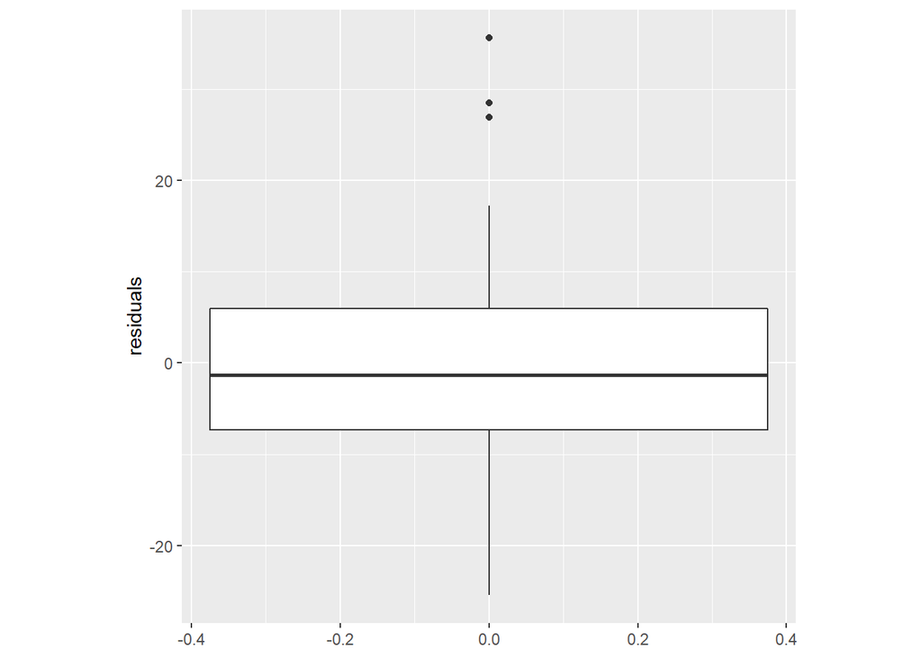

```r
#Boxplot
stop_boxplot
```

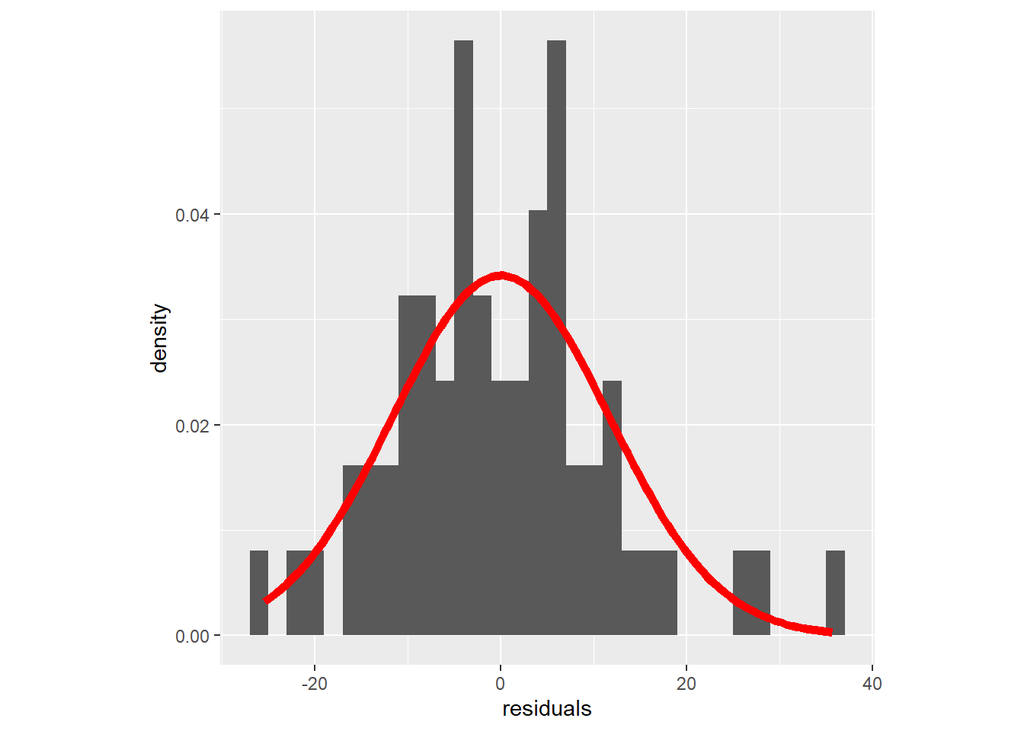

```r
#Histogram
stop_hist
```

The histogram tells us that the values in the mass on the far-right tail may be outliers, but it is not easily apparent. The Cook’s distance formula tells us that there are four outliers, while, when looking at the associated graph, there appear to be two (maybe three) outliers. Our boxplot indicates that we have three outliers.

#### 12. Speculate whether additional predictor variables are not required (no diagnostic tools - just think about the variables you have and if there are other variables you think would help predict the response)

When looking at the scatterplot, one could conclude that there may be an exponential relationship between stopping distance and car speed, but it may take some convincing to get others to conclude that. Thus, with the current information, I do not think there are any additionally significant predictor variables.

#### 13. Based on your analysis of the diagnostic measures, briefly discuss why this simple linear regression model on the raw data (not transformed) is *not* appropriate.

One may be comfortable accepting the linearity assumption given our data, but others may not. It is, however, abundantly clear that the equal variance assumption should be rejected, based on both the Breusch-Pagan test and visual inspection of the Residual v. fitted values plot.

#### 14. Fix the model by making any necessary transformations. Justify the transformation you chose in words (why did you choose to transform just x, just y, or both?). (Note: if boxCox(mod) throws an error, replace mod with the formula for the linear model, y ~ x.) (Note: you will most likely need to repeat questions 14 and 18 until you are satisfied with the transformation you chose. Only then should you fill out this section - I only want to see the model you end up choosing, not all of your attempted models.)

```r
bc <- boxCox(stop$Distance ~ stop$Speed)
```

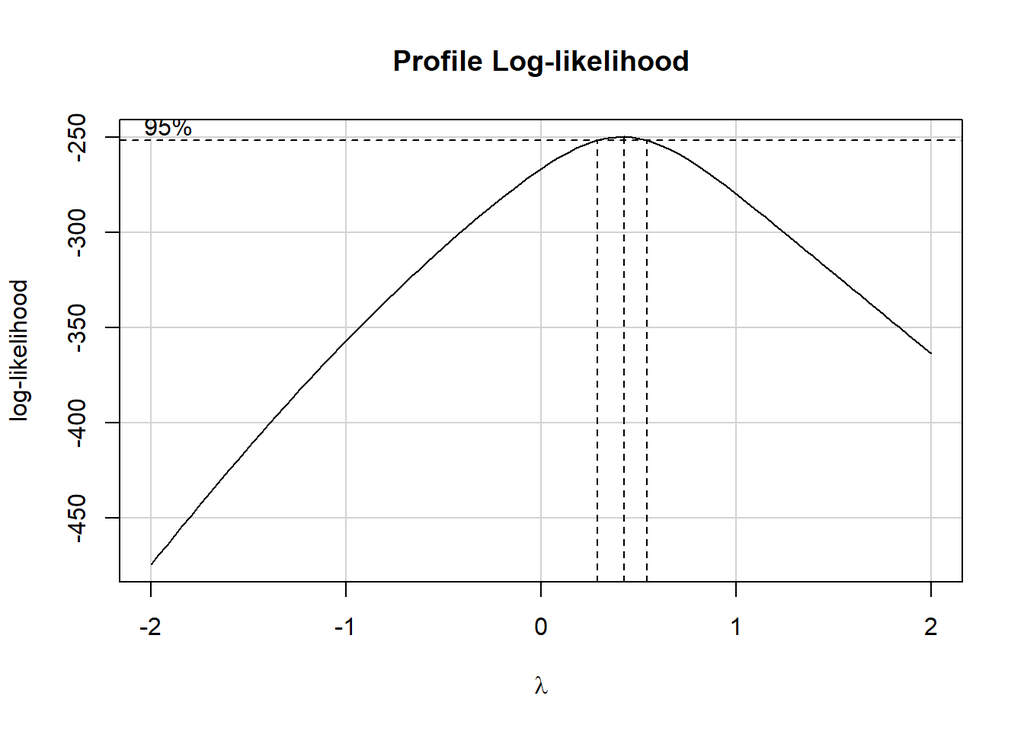

```r
bc$x[which.max(bc$y)]
```

```
## [1] 0.4242424
```

```r
#sqrty
stop$Distance_sqrt <- sqrt(stop$Distance)
stop_sqrt.lm<-lm(Distance_sqrt ~ Speed, data = stop)
summary(stop_sqrt.lm)
```

```
##
## Call:
## lm(formula = Distance_sqrt ~ Speed, data = stop)
##
## Residuals:
##      Min       1Q   Median       3Q      Max
## -1.49948 -0.54761  0.00469  0.53153  1.54350
##
## Coefficients:
##             Estimate Std. Error t value Pr(>|t|)
## (Intercept) 0.932396   0.197909   4.711  1.5e-05 ***
## Speed       0.252466   0.009274  27.223  < 2e-16 ***
## ---
## Signif. codes:  0 '***' 0.001 '**' 0.01 '*' 0.05 '.' 0.1 ' ' 1
##
## Residual standard error: 0.7209 on 60 degrees of freedom
## Multiple R-squared:  0.9251, Adjusted R-squared:  0.9239
## F-statistic: 741.1 on 1 and 60 DF,  p-value: < 2.2e-16
```

```r
stop$residuals_sqrt <- stop_sqrt.lm$residuals
stop$fittedDistance_sqrt <- stop_sqrt.lm$fitted.values
```

### Now, in Questions 15-18, re-check your transformed model and verify that the assumptions (the assumptions that were addressed in the questions above) are met. Provide a brief discussion about how each of the previously violated assumptions are now satisfied. Also, provide the code you used to assess adherence to the assumptions. (Note that transforming will not change your responses about (I) the residuals being independent and (R) additional predictor variables not being required, so we will skip these assumptions here.)

#### 15. (L) Linearity (use at least two diagnostic tools)

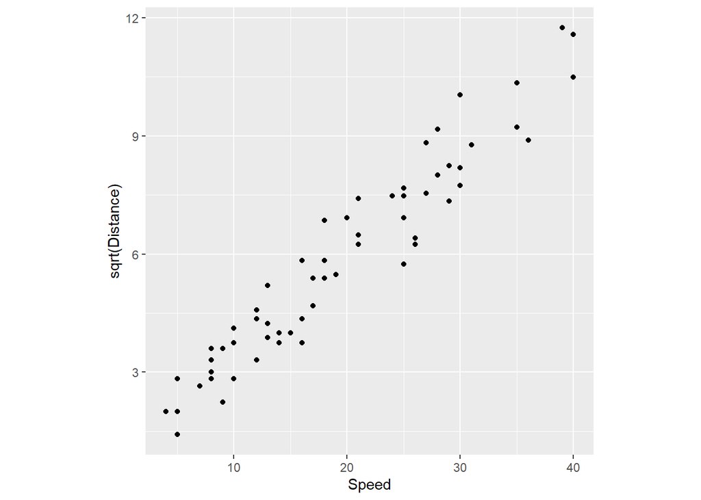

```r
#sqrty
ggplot(data = stop) +
  geom_point(mapping = aes(x = Speed, y = Distance_sqrt)) +
  ylab("sqrt(Distance)") +
  theme(aspect.ratio = 1)
```

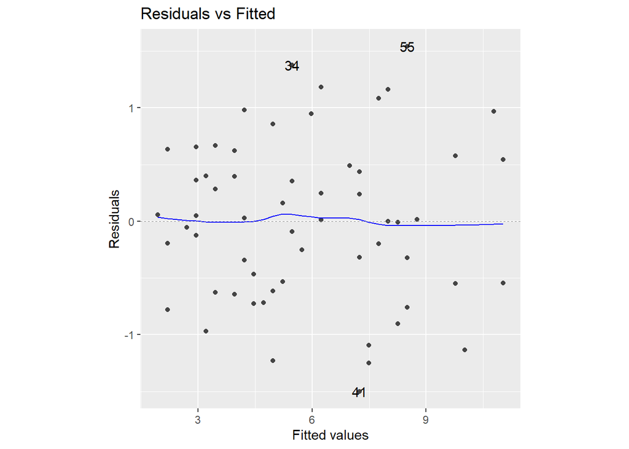

```r
stop_resid_vs_fit_sqrt <- autoplot(stop_sqrt.lm,
                                    which = 1, ncol = 1, nrow = 1) +
  theme(aspect.ratio = 1)
stop_resid_vs_fit_sqrt
```

In the scatterplot, the trend appears linear, so this assumption appears to be met. In our Residual v. fitted plot, our solid, colored line roughly follows the dotted, horizontal line at 0, suggesting that we can assume a linear relationship between Distance to stop and Speed.

#### 16. (N) The residuals are normally distributed and centered at zero (use at least three diagnostic tools)

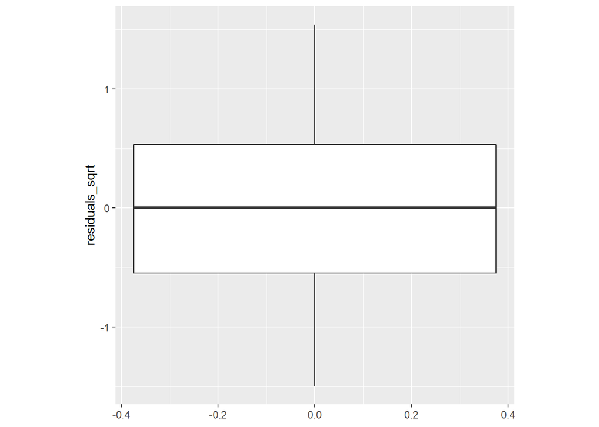

```r
#Boxplot
stop_boxplot_sqrt <- ggplot(data = stop) +
  geom_boxplot(mapping = aes(y = residuals_sqrt)) +
  theme(aspect.ratio = 1)
stop_boxplot_sqrt
```

[figure not shown]

```r
#Histogram
stop_hist_sqrt <- ggplot(data = stop) +
  geom_histogram(mapping = aes(x = residuals_sqrt, y = ..density..), #..density.. allows us to compare to a normal curve
                 binwidth = 2) +
  stat_function(fun = dnorm, #overlays normal curve
                color = "red",
                size = 2,
                args = list(mean = mean(stop$residuals),
                            sd = sd(stop$residuals))) +
  theme(aspect.ratio = 1)
stop_hist_sqrt
```

```r
#Wilk-Shapiro Test
shapiro.test(stop$residuals_sqrt)
```

```
##
##  Shapiro-Wilk normality test
##
## data:  stop$residuals_sqrt
## W = 0.98801, p-value = 0.8072
```

Our boxplot is nearly perfect in every way. It is centered at zero, has nearly identically sized boxes and whiskers, respectively, and has no outliers. A similar things could be said about our histogram as it displays no skewness. The Wilk-Shapiro test result of a .8072 p-value tells us that we fail to reject the normality assumption.

#### 17. (E) The residuals have equal/constant variance across all values of X (use two diagnostic tools)

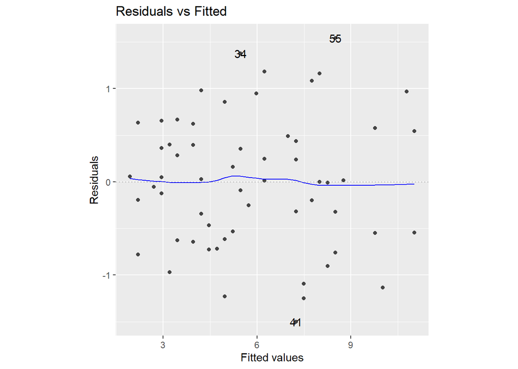

```r
#Resid v. fitted
stop_resid_vs_fit_sqrt
```

```r
#Breusch-Pagan
lmtest::bptest(stop_sqrt.lm)
```

```
##
##  studentized Breusch-Pagan test
##
## data:  stop_sqrt.lm
## BP = 3.5597, df = 1, p-value = 0.0592
```

The residuals should be equally spread around the horizontal line. That is largely true. The Breusch-Pagan test, with a .0592 p-value, does not give us strong grounds to reject the equal variance assumption.

#### 18. Examine whether there are no influential points (use at least three diagnostic tools)

[figure not shown]

```r
#Histogram
stop_hist_sqrt
```

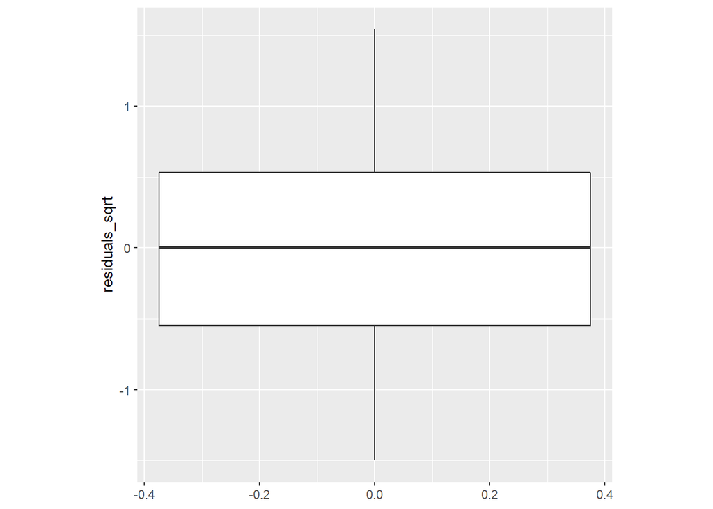

```r
#Boxplot
stop_boxplot_sqrt
```

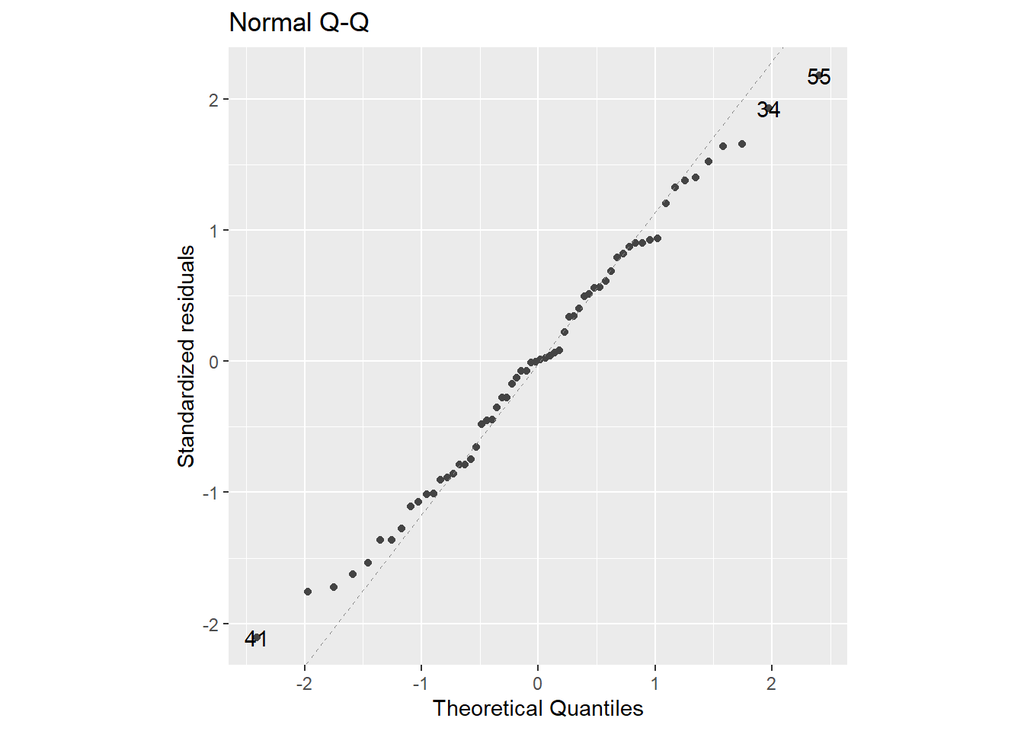

```r
#QQ-Plot
stop_qq_sqrt <- autoplot(stop_sqrt.lm, which = 2, ncol = 1, nrow = 1) +
  theme(aspect.ratio = 1)
stop_qq_sqrt
```

According to both the histogram and the boxplot, there are no outliers. When looking at the QQ-plot, we notice possible outliers, but they are not easily identifiable as such.

#### 20. Plot your new fitted *curve* on the scatterplot of the original data (on the original scale - not the transformed scale). Do you think this curve fits the data better than the line you previously fit?

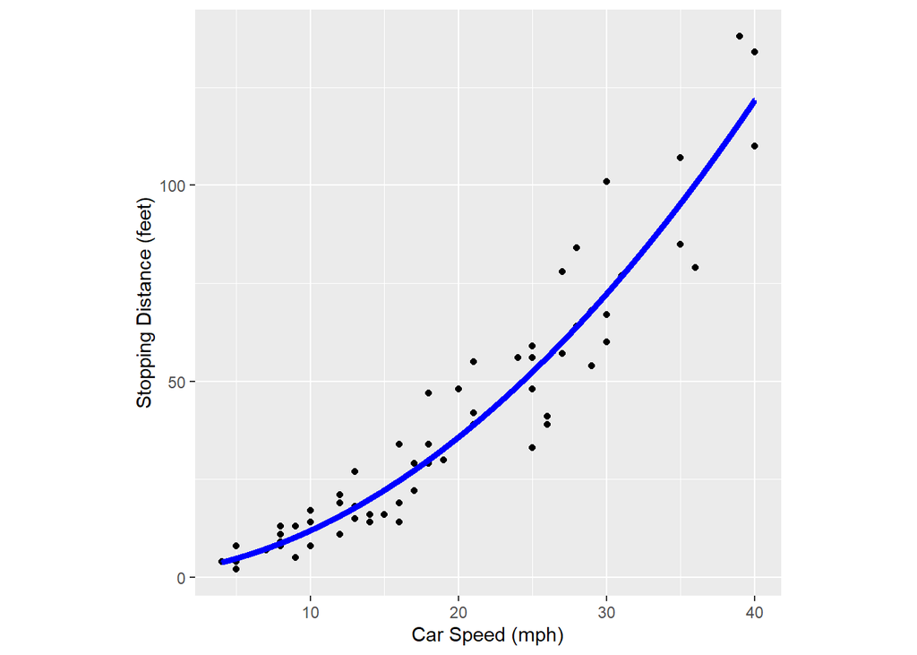

```r
Speed_values <- seq(min(stop$Speed),
                     max(stop$Speed),
                     length = 10000)
# Predictions of **sqrt(Distance)** across those values of Speed
sqrt_Distance_preds <- predict(stop_sqrt.lm,
                         newdata = data.frame(Speed = Speed_values))
# Predictions of **Distance** (back-transformed) across those value of Speed
Distance_preds <- (sqrt_Distance_preds)^2  # use ^2 to "undo" the sqrt transform
# Store results in a data frame for plotting
preds <- data.frame("Speed_values" = Speed_values,
                    "Distance_preds" = Distance_preds)
# Plot the predictions on the original scale (to get a curved line)
stop_base_plot +
  geom_line(data = preds,
            mapping = aes(x = Speed_values, y = Distance_preds),
            size = 1.5, color ="blue")
```

This looks like a more accurate estimation of the trend that describes the relationship between Car Speed and Stopping Distance.